# Problem Statement

In this Use Case we will be working with Social Network Ads data set, we will be dealing with all the user details that are given in the time of registering.

With this data, we will try to create a model that will predict, whether the new user will buy the new SUV or not, based on the details of the user given at the time of registeration.

We will be using all types of classification models and we choose which model provide us high accuracy.

Models:

1. Logistic Regression
2. Decision Tree
3. Random Forest
4. KNN Classifier

## Import Libraries

```python
import pandas as pd
import numpy as np
import matplotlib.pyplot as plt
import seaborn as sns
%matplotlib inline

import warnings
warnings.filterwarnings('ignore')
from sklearn.metrics import classification_report,confusion_matrix
```

## Importing Datasets

```python
data=pd.read_csv('F:\pythonProject\Vignesh Programming\Classification KNN,DT,RF,LR\Social_Network_Ads.csv')
data.describe()
```

|  | User ID | Age | EstimatedSalary | Purchased |
| --- | --- | --- | --- | --- |
| count | 4.000000e+02 | 400.000000 | 400.000000 | 400.000000 |
| mean | 1.569154e+07 | 37.655000 | 69742.500000 | 0.357500 |
| std | 7.165832e+04 | 10.482877 | 34096.960282 | 0.479864 |
| min | 1.556669e+07 | 18.000000 | 15000.000000 | 0.000000 |
| 25% | 1.562676e+07 | 29.750000 | 43000.000000 | 0.000000 |
| 50% | 1.569434e+07 | 37.000000 | 70000.000000 | 0.000000 |
| 75% | 1.575036e+07 | 46.000000 | 88000.000000 | 1.000000 |
| max | 1.581524e+07 | 60.000000 | 150000.000000 | 1.000000 |

```python
data.head()
```

|  | User ID | Gender | Age | EstimatedSalary | Purchased |
| --- | --- | --- | --- | --- | --- |
| 0 | 15624510 | Male | 19 | 19000 | 0 |
| 1 | 15810944 | Male | 35 | 20000 | 0 |
| 2 | 15668575 | Female | 26 | 43000 | 0 |
| 3 | 15603246 | Female | 27 | 57000 | 0 |
| 4 | 15804002 | Male | 19 | 76000 | 0 |

## Exploratory Data Analysis

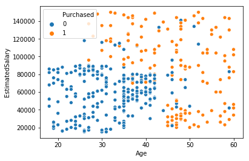

```python
sns.scatterplot('Age','EstimatedSalary', data=data, hue='Purchased')
```

From the plot we could found that if age is above 40 and salary is above 80,000 there is a high possibility of buying the SUV

## 1. KNN CLASSIFIER MODEL

```python
from sklearn.preprocessing import StandardScaler
#Standardize  the data to a common scale
scaler= StandardScaler()
#scaler=data.iloc[:,range(2,5)]
scaled_features= scaler.fit_transform(data[['Age','EstimatedSalary']])
df=pd.DataFrame(scaled_features,columns=['Age','EstimatedSalary'])
df.tail()
```

|  | Age | EstimatedSalary |
| --- | --- | --- |
| 395 | 0.797057 | -0.844019 |
| 396 | 1.274623 | -1.372587 |
| 397 | 1.179110 | -1.460681 |
| 398 | -0.158074 | -1.078938 |
| 399 | 1.083596 | -0.990844 |

```python
#from sklearn.cross_validation import  train_test_split
from sklearn.model_selection import train_test_split
X= df
y= data['Purchased']
X_train, X_test, y_train, y_test = train_test_split(X,y,test_size=0.3,random_state=101)
```

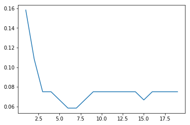

```python
from sklearn.neighbors import KNeighborsClassifier
#Elbow method to determine the optimal K value
error_rate=[]
for i in range(1,20):
 knn=KNeighborsClassifier(n_neighbors=i)
 knn.fit(X_train,y_train)
 pred_i = knn.predict(X_test)
 error_rate.append(np.mean(pred_i != y_test))

plt.plot(range(1,20),error_rate)
```

```python
#Build the Model with 7 as K
knn=KNeighborsClassifier(n_neighbors=7)
knn.fit(X_train,y_train)

# Predict and Evaluate the Model
pred = knn.predict(X_test)
print(confusion_matrix(y_test,pred))
print(classification_report(y_test,pred))
```

```
[[74  6]
 [ 1 39]]
              precision    recall  f1-score   support

           0       0.99      0.93      0.95        80
           1       0.87      0.97      0.92        40

   micro avg       0.94      0.94      0.94       120
   macro avg       0.93      0.95      0.94       120
weighted avg       0.95      0.94      0.94       120
```

## 2. Decision Tree MODEL

```python
from sklearn.tree import DecisionTreeClassifier
dtree = DecisionTreeClassifier()
```

## Train & Test Data Split

Split the data into training set and testing set using train_test_split

```python
from sklearn.model_selection import train_test_split
X= data.iloc[:,[2,3]].values
y=data.iloc[:,4].values
X_train, X_test, y_train, y_test = train_test_split(X, y, test_size=0.30, random_state=101)
dtree.fit(X_train,y_train)
```

```
DecisionTreeClassifier(class_weight=None, criterion='gini', max_depth=None,
            max_features=None, max_leaf_nodes=None,
            min_impurity_decrease=0.0, min_impurity_split=None,
            min_samples_leaf=1, min_samples_split=2,
            min_weight_fraction_leaf=0.0, presort=False, random_state=None,
            splitter='best')
```

```python
predictions = dtree.predict(X_test)
from sklearn.metrics import classification_report,confusion_matrix
print(confusion_matrix(y_test,predictions))
print(classification_report(y_test,predictions))
```

```
[[70 10]
 [ 5 35]]
              precision    recall  f1-score   support

           0       0.93      0.88      0.90        80
           1       0.78      0.88      0.82        40

   micro avg       0.88      0.88      0.88       120
   macro avg       0.86      0.88      0.86       120
weighted avg       0.88      0.88      0.88       120
```

## 3. Random Forest model

```python
from sklearn.ensemble import RandomForestClassifier
rfc = RandomForestClassifier(n_estimators=100) # Let us keep 100 trees
```

## Train & Test Data Split

Split the data into training set and testing set using train_test_split

```python
from sklearn.model_selection import train_test_split
X= data.iloc[:,[2,3]].values
y=data.iloc[:,4].values
X_train, X_test, y_train, y_test = train_test_split(X, y, test_size=0.30, random_state=101)
rfc.fit(X_train, y_train)
```

```
RandomForestClassifier(bootstrap=True, class_weight=None, criterion='gini',
            max_depth=None, max_features='auto', max_leaf_nodes=None,
            min_impurity_decrease=0.0, min_impurity_split=None,
            min_samples_leaf=1, min_samples_split=2,
            min_weight_fraction_leaf=0.0, n_estimators=100, n_jobs=None,
            oob_score=False, random_state=None, verbose=0,
            warm_start=False)
```

```python
rfc_pred = rfc.predict(X_test)
print(confusion_matrix(y_test,rfc_pred))
print(classification_report(y_test,rfc_pred))
```

```
[[71  9]
 [ 1 39]]
              precision    recall  f1-score   support

           0       0.99      0.89      0.93        80
           1       0.81      0.97      0.89        40

   micro avg       0.92      0.92      0.92       120
   macro avg       0.90      0.93      0.91       120
weighted avg       0.93      0.92      0.92       120
```

## 4. Logistic Regression

```python
from sklearn.linear_model import LogisticRegression
lr = LogisticRegression()
```

## Train & Test Data Split

Split the data into training set and testing set using train_test_split

```python
from sklearn.model_selection import train_test_split
X= data.iloc[:,[2,3]].values
y=data.iloc[:,4].values
X_train, X_test, y_train, y_test = train_test_split(X, y, test_size=0.30, random_state=101)
lr.fit(X_train, y_train)
```

```
LogisticRegression(C=1.0, class_weight=None, dual=False, fit_intercept=True,
          intercept_scaling=1, max_iter=100, multi_class='warn',
          n_jobs=None, penalty='l2', random_state=None, solver='warn',
          tol=0.0001, verbose=0, warm_start=False)
```

```python
pred = lr.predict(X_test)
print(confusion_matrix(y_test,pred))
print(classification_report(y_test,pred))
```

```
[[80  0]
 [40  0]]
              precision    recall  f1-score   support

           0       0.67      1.00      0.80        80
           1       0.00      0.00      0.00        40

   micro avg       0.67      0.67      0.67       120
   macro avg       0.33      0.50      0.40       120
weighted avg       0.44      0.67      0.53       120
```

## Result

Out of the four, KNN Classifier gives more Accuracy. So, For the Social Network Ads Model, we can suggest K Nearest Neighbor Algorithm gives the Best accuracy.